```python
import pandas as pd
import numpy as np
import nltk
from nltk.sentiment import SentimentIntensityAnalyzer
```

```python
imdb = pd.read_csv("D:/Third_Sem/Dataset/imdb_sentiment.csv")
imdb.head()
```

|  | review | sentiment |
| --- | --- | --- |
| 0 | A very, very, very slow-moving, aimless movie ... | 0 |
| 1 | Not sure who was more lost - the flat characte... | 0 |
| 2 | Attempting artiness with black & white and cle... | 0 |
| 3 | Very little music or anything to speak of. | 0 |
| 4 | The best scene in the movie was when Gerardo i... | 1 |

# VADER

- Valence Aware Dictonary and Sentiment Reasoner
- This SentimentIntensityAnalyzer library used for small dataset

```python
sentiment = SentimentIntensityAnalyzer()
sentiment.polarity_scores('I Love India')
```

```
{'neg': 0.0, 'neu': 0.192, 'pos': 0.808, 'compound': 0.6369}
```

```python
#! pip install textblob
```

```python
#! pip install tweepy
```

```python
sentiment.polarity_scores('I love india i hate apple')
```

```
{'neg': 0.374, 'neu': 0.202, 'pos': 0.424, 'compound': 0.128}
```

```python
### adding +1 to get the score for pos and -1 to get neg
#### EG:- pos :- 3.2
####      neg :- 1
####      neu :- 1
#### % of pos score = (3.2+1)/(4.2+1)
#### % of neg score = (0)/(4.2+1)
#### % of neutral score = (1)/(4.2+1)
### we generally not consider neutral score in our overall score, and we need to to normalization
#### eg:- Score=3.4
#### alpha=15
#### Compound= score/sqrt(Score)^2 + alpha
```

### Data

```python
def get_sentiment(text):
    sentiment = SentimentIntensityAnalyzer()
    compound = sentiment.polarity_scores(text)['compound']
    if compound >0:
        return 1
    else:
        return 0
```

```python
imdb['sentiment_vader'] = imdb['review'].apply(get_sentiment)
```

```python
imdb.head()
```

|  | review | sentiment | sentiment_vader |
| --- | --- | --- | --- |
| 0 | A very, very, very slow-moving, aimless movie ... | 0 | 0 |
| 1 | Not sure who was more lost - the flat characte... | 0 | 0 |
| 2 | Attempting artiness with black & white and cle... | 0 | 0 |
| 3 | Very little music or anything to speak of. | 0 | 0 |
| 4 | The best scene in the movie was when Gerardo i... | 1 | 1 |

```python
from sklearn.metrics import accuracy_score
```

```python
accuracy_score(imdb['sentiment'],imdb['sentiment_vader'])
```

```
0.7941176470588235
```

# Topics

- Basic features extraction from text data
- Text cleaning / Trnasformation
- Text Classification
- Bag of word analysis
- Text Clustering
- Sentiment analysis (supervised, unsupervised)

# Word Similiarity

```python
amazon = pd.read_csv("D:/Third_Sem/Dataset/amazon_reviews.csv")
amazon.head()
```

|  | Unnamed: 0 | asin | helpful | overall | reviewText | reviewTime | reviewerID | reviewerName | summary | unixReviewTime |
| --- | --- | --- | --- | --- | --- | --- | --- | --- | --- | --- |
| 0 | 0 | 0528881469 | [0, 0] | 5.0 | We got this GPS for my husband who is an (OTR)... | 06 2, 2013 | AO94DHGC771SJ | amazdnu | Gotta have GPS! | 1.370131e+09 |
| 1 | 1 | 0528881469 | [12, 15] | 1.0 | I'm a professional OTR truck driver, and I bou... | 11 25, 2010 | AMO214LNFCEI4 | Amazon Customer | Very Disappointed | 1.290643e+09 |
| 2 | 2 | 0528881469 | [43, 45] | 3.0 | Well, what can I say. I've had this unit in m... | 09 9, 2010 | A3N7T0DY83Y4IG | C. A. Freeman | 1st impression | 1.283990e+09 |
| 3 | 3 | 0528881469 | [9, 10] | 2.0 | Not going to write a long review, even thought... | 11 24, 2010 | A1H8PY3QHMQQA0 | Dave M. Shaw "mack dave" | Great grafics, POOR GPS | 1.290557e+09 |
| 4 | 4 | 0528881469 | [0, 0] | 1.0 | I've had mine for a year and here's what we go... | 09 29, 2011 | A24EV6RXELQZ63 | Wayne Smith | Major issues, only excuses for support | 1.317254e+09 |

```python
amazon.isnull().sum()
```

```
Unnamed: 0        0
asin              0
helpful           0
overall           0
reviewText        2
reviewTime        0
reviewerID        0
reviewerName      5
summary           0
unixReviewTime    0
dtype: int64
```

```python
docs = amazon['reviewText'].fillna('').str.lower().str.replace('[^a-z ]','')
docs.head()
```

```
0    we got this gps for my husband who is an otr o...
1    im a professional otr truck driver and i bough...
2    well what can i say  ive had this unit in my t...
3    not going to write a long review even thought ...
4    ive had mine for a year and heres what we got ...
Name: reviewText, dtype: object
```

```python
stopwords = nltk.corpus.stopwords.words('english')
stemmer = nltk.stem.PorterStemmer()
```

```python
def clean_sentence(text):
    words = text.split(' ')
    words_clean = [stemmer.stem(word) for word in words if word not in stopwords]
    return ' '.join(words_clean)
```

```python
docs_clean = docs.apply(clean_sentence)
docs_clean.head()
```

```
0    got gp husband otr road trucker  impress ship ...
1    im profession otr truck driver bought tnd  tru...
2    well say  ive unit truck four day  prior garmi...
3    go write long review even thought unit deserv ...
4    ive mine year here got tri rout non truck rout...
Name: reviewText, dtype: object
```

```python
from sklearn.feature_extraction.text import CountVectorizer
```

```python
vectorizer = CountVectorizer()
vectorizer.fit(docs_clean)
```

```
CountVectorizer(analyzer='word', binary=False, decode_error='strict',
        dtype=<class 'numpy.int64'>, encoding='utf-8', input='content',
        lowercase=True, max_df=1.0, max_features=None, min_df=1,
        ngram_range=(1, 1), preprocessor=None, stop_words=None,
        strip_accents=None, token_pattern='(?u)\\b\\w\\w+\\b',
        tokenizer=None, vocabulary=None)
```

```python
df_dtm = pd.DataFrame(vectorizer.transform(docs_clean).toarray(),columns=vectorizer.get_feature_names())
df_dtm.shape
```

```
(999, 7172)
```

```python
from sklearn.metrics.pairwise import cosine_similarity
```

```python
cosine_similarity([df_dtm['tablet'],df_dtm['nook']])
```

```
array([[1.        , 0.41595326],
       [0.41595326, 1.        ]])
```

```python
cosine_similarity([df_dtm['kindl'],df_dtm['nook']])
```

```
array([[1.        , 0.67552303],
       [0.67552303, 1.        ]])
```

```python
cosine_similarity([df_dtm['kindl'],df_dtm['camera']])
```

```
array([[1.        , 0.06940188],
       [0.06940188, 1.        ]])
```

```python
def get_similar_words(input_word, sim_mat):

    return similar_words
```

```python
# T will we used for compare the rowwise if we not take. T used for transpose
sim_mat = cosine_similarity(df_dtm.T)
sim_matrix
```

[output not shown]

```python
sim_mat = pd.DataFrame(sim_mat,columns=df_dtm.columns,index=df_dtm.columns)
sim_mat.head(2)
```

|  | aaa | aac | abandon | abil | abl | abnorm | aboutdo | aboutif | absenc | absent | ... | zbox | zero | zillion | zip | zipper | zippi | zippier | zirco | zoom | zune |
| --- | --- | --- | --- | --- | --- | --- | --- | --- | --- | --- | --- | --- | --- | --- | --- | --- | --- | --- | --- | --- | --- |
| aaa | 1.0 | 0.0 | 0.0 | 0.000000 | 0.0 | 0.0 | 0.0 | 0.0 | 0.0 | 0.0 | ... | 0.0 | 0.0 | 0.0 | 0.0 | 0.0 | 0.0 | 0.0 | 0.0 | 0.0 | 0.0 |
| aac | 0.0 | 1.0 | 0.0 | 0.100504 | 0.0 | 0.0 | 0.0 | 0.0 | 0.0 | 0.0 | ... | 0.0 | 0.0 | 0.0 | 0.0 | 0.0 | 0.0 | 0.0 | 0.0 | 0.0 | 0.0 |

2 rows × 7172 columns

```python
sim_mat['tablet'].sort_values(ascending=False).head(5)
```

```
tablet     1.000000
app        0.625789
android    0.572984
invit      0.534830
version    0.513131
Name: tablet, dtype: float64
```

```python
def get_similar_words(input_word, sim_mat):
    cos_vals = sim_mat[input_word].sort_values(ascending=False)
    similar_words = cos_vals.drop(input_word).head(5)
    return similar_words
```

```python
get_similar_words('camera',sim_mat)
```

```
avi              0.438397
tout             0.410997
expectationth    0.410997
kiddingnow       0.410997
advanceon        0.410997
Name: camera, dtype: float64
```

```python
get_similar_words('kindl',sim_mat)
```

```
nook      0.675523
like      0.582769
touch     0.549399
amazon    0.546405
read      0.546357
Name: kindl, dtype: float64
```

### Topic Modeling (Basicaly used for e-comm, and real based products category)

- "Topic modeling is a of statistical model for discovering the abstract topics that occur in a collection of documents" -- Wikipedia
- "Topic modeling helps to discover and annotate large documents with hidden topics" -- Lin Liu et al

### Example

- Topic the Tag
- Amazon has great customer support. Very quick response - Customer Support
- Delivery speed is good. Great packing - Delivery
- Got a damaged packing from Amazon. Need a repalcement -- Delivery
- Deals are quite good. Good offers --- Deals

Term Define topics -- Customer Support Delivery Deals -- Support Speed Offers -- Service Packing Sales -- Call Center Damaged Promotions -- Response Protection Coupons

# Popular Methods (Topic Modeling)

--1) Latent Sematic Alaysis (LSA) --2)Latent Dirichlet Allocation (LDA)

- Latent Dirichlet Allocation used for large Dataset for better result

```python
#!pip install gensim
```

```python
import gensim
```

```python
amazon = pd.read_csv("D:/Third_Sem/Dataset/amazon_reviews_big/amazon_reviews_big.csv")
amazon.head()
```

|  | asin | overall | reviewText | reviewTime | reviewerID | reviewerName | summary | unixReviewTime |
| --- | --- | --- | --- | --- | --- | --- | --- | --- |
| 0 | B000HDJXNA | 1 | What I recieved is not what is pictured here O... | 12 26, 2012 | A29YXBFTD7QUP3 | HHA | Buyer be ware | 1.356480e+09 |
| 1 | B006KKS7XQ | 5 | Excellent unit and a pretty simple install usi... | 09 20, 2013 | A3IMTXFYD7CGDN | Peter W. George "soyflakeman" | high quality without high price | 1.379635e+09 |
| 2 | B002NP8XJ0 | 5 | I'm enjoying this keyboard, I'm getting anothe... | 08 31, 2010 | AXNOW20FQKHVW | B. Hayashi | Superb keyboard + solution for slow wake up an... | 1.283213e+09 |
| 3 | B000EITTLE | 4 | Overall, this is a fantastic camera that I'm e... | 02 3, 2008 | A10KCAK279LO0W | mmcwatters "macdadi80" | One qualm: not great in low light | 1.201997e+09 |
| 4 | B006CRXK4S | 5 | These work very well with mySamsung PN64D7000 ... | 01 28, 2012 | A19XXLMZXR764J | S. Garfinkle | Work great, fit well | 1.327709e+09 |

```python
amazon.shape
```

```
(100000, 8)
```

```python
amazon.isnull().sum()
```

```
asin                 0
overall              0
reviewText          66
reviewTime           0
reviewerID           0
reviewerName        26
summary              0
unixReviewTime    1479
dtype: int64
```

```python
docs_clean = []
docs = amazon['reviewText'].fillna('').str.lower().str.replace('[^a-z ]','')
docs.head()
```

```
0    what i recieved is not what is pictured here o...
1    excellent unit and a pretty simple install usi...
2    im enjoying this keyboard im getting another o...
3    overall this is a fantastic camera that im ext...
4    these work very well with mysamsung pnd inch p...
Name: reviewText, dtype: object
```

```python
stopwards = nltk.corpus.stopwords.words('english')
stopwards.extend(['','use','good','like','great','work','one'])
stemmer = nltk.stem.PorterStemmer()
```

```python
for doc in docs:
    words = doc.split(' ')
    words_clean = [stemmer.stem(word) for word in words if word not in stopwards]
    docs_clean.append(words_clean)
len(docs_clean)
```

```
100000
```

```python
dictionary = gensim.corpora.Dictionary(docs_clean)
dictionary
```

```
<gensim.corpora.dictionary.Dictionary at 0x2bcf1343f60>
```

```python
dictionary.token2id['amazon']
```

```
508
```

```python
list(zip(dictionary.keys(), dictionary.values()))
```

[output not shown]

[output cut: 946 more lines]

```
 (986, 'choos'),
 (987, 'clunki'),
 (988, 'code'),
 (989, 'complain'),
 (990, 'condit'),
 (991, 'copi'),
 (992, 'corner'),
 (993, 'crack'),
 (994, 'craft'),
 (995, 'cream'),
 (996, 'dark'),
 (997, 'default'),
 (998, 'deliv'),
 (999, 'develop'),
 ...]
```

```python
#frequency of each unique word for each document and given the list
docs_bow = []
for doc in docs_clean:
    doc_bow = dictionary.doc2bow(doc)
    docs_bow.append(doc_bow)
```

```python
#dictionary.doc2bow(docs_clean[0])
```

```python
# num_topics is as a kmens (num_topice=4)
lda_model = gensim.models.LdaModel(docs_bow,id2word=dictionary,num_topics=4)
```

```python
lda_model
```

```
<gensim.models.ldamodel.LdaModel at 0x2bc9d3fe3c8>
```

```python
lda_model.get_document_topics(docs_bow[0])
```

```
[(1, 0.38204524), (2, 0.05016703), (3, 0.5635952)]
```

```python
lda_model.print_topics()
```

```
[(0,
  '0.023*"camera" + 0.022*"drive" + 0.016*"card" + 0.014*"len" + 0.008*"use" + 0.007*"gb" + 0.006*"usb" + 0.006*"canon" + 0.006*"flash" + 0.006*"mm"'),
 (1,
  '0.021*"sound" + 0.013*"cabl" + 0.012*"tv" + 0.011*"speaker" + 0.010*"qualiti" + 0.008*"headphon" + 0.007*"get" + 0.007*"price" + 0.006*"music" + 0.006*"use"'),
 (2,
  '0.016*"case" + 0.008*"well" + 0.008*"work" + 0.008*"fit" + 0.008*"use" + 0.007*"would" + 0.007*"keyboard" + 0.006*"look" + 0.006*"usb" + 0.006*"need"'),
 (3,
  '0.009*"get" + 0.008*"batteri" + 0.008*"time" + 0.007*"work" + 0.007*"use" + 0.007*"would" + 0.006*"set" + 0.005*"devic" + 0.005*"screen" + 0.005*"product"')]
```

```python
#doc2topic_prob=lda_model.get_document_topics(docs_bow[0])
topics=[]
for doc_bow in docs_bow:
    doc2topic_prob=lda_model.get_document_topics(doc_bow)
    doc2topic_prob = pd.DataFrame(doc2topic_prob, columns = ['topic','prob'])
    topic = doc2topic_prob.sort_values('prob',ascending=False).iloc[0]['topic']
    topics.append(topic)
```

```python
amazon['topics'] = topics
amazon['topics'].value_counts()
```

```
2.0    33553
3.0    29920
1.0    20910
0.0    15617
Name: topics, dtype: int64
```

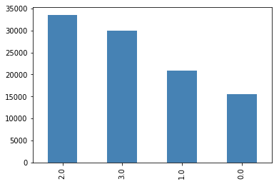

```python
%matplotlib inline
amazon['topics'] = topics
amazon['topics'].value_counts().plot.bar(color='steelblue')
```

# Exercise

- Use Hotstar data, predict sentiment for the Reviews column using vader package
- Convert score to labels

  ```
    - Positive (score >0.05)
    - Negative (score < -0.05) and Netural)
    - and Nutral  (-0.05 <= score <= 0.05)
  ```

- Calculate accuracy score
- Comapre the accuracy with supervised model and comment whether supervised or unsupervised gives best accuracy
- Create a multi-line chart for comparing no. of positive, negative and neutral reviews for each day (we have one week data)

```python
hotstar = pd.read_csv("D:/Third_Sem/Dataset/hotstar.allreviews_Sentiments.csv")
hotstar.head()
```

|  | ID | UserName | Created_Date | Reviews | Lower_Case_Reviews | Sentiment_Manual_BP | Sentiment_Manual | Review_Length | DataSource | Year | Month | Date | Sentiment_Polarity |
| --- | --- | --- | --- | --- | --- | --- | --- | --- | --- | --- | --- | --- | --- |
| 0 | 1 | NaN | 8/10/2017 | Hh | hh | Negative | Negative | 2 | Google_PlayStore | 2017 | 8 | 10 | Neutral |
| 1 | 2 | NaN | 8/11/2017 | No | no | Negative | Negative | 2 | Google_PlayStore | 2017 | 8 | 11 | Neutral |
| 2 | 3 | asadynwa | 8/12/2017 | @hotstar_helps during paymnt for premium subsc... | @hotstar_helps during paymnt for premium subsc... | Help | Negative | 140 | Twitter | 2017 | 8 | 12 | Negative |
| 3 | 4 | jineshroxx | 8/11/2017 | @hotstartweets I am currently on Jio network a... | @hotstartweets i am currently on jio network a... | Help | Negative | 140 | Twitter | 2017 | 8 | 11 | Positive |
| 4 | 5 | YaminiSachar | 8/5/2017 | @hotstartweets the episodes of Sarabhai vs Sar... | @hotstartweets the episodes of sarabhai vs sar... | Help | Negative | 140 | Twitter | 2017 | 8 | 5 | Neutral |

```python
sentiment = SentimentIntensityAnalyzer()
```

```python
def get_sentiment(text):
    sentiment = SentimentIntensityAnalyzer()
    compound = sentiment.polarity_scores(text)['compound']
    if compound >0.05:
        return 'Positive'
    if compound <-0.05:
        return 'Negative'
    else:
        return 'Neutral'
```

```python
hotstar['sentiment_vader'] = hotstar['Reviews'].apply(get_sentiment)
```

```python
hotstar.head(2)
```

|  | ID | UserName | Created_Date | Reviews | Lower_Case_Reviews | Sentiment_Manual_BP | Sentiment_Manual | Review_Length | DataSource | Year | Month | Date | Sentiment_Polarity | sentiment_vader |
| --- | --- | --- | --- | --- | --- | --- | --- | --- | --- | --- | --- | --- | --- | --- |
| 0 | 1 | NaN | 8/10/2017 | Hh | hh | Negative | Negative | 2 | Google_PlayStore | 2017 | 8 | 10 | Neutral | Neutral |
| 1 | 2 | NaN | 8/11/2017 | No | no | Negative | Negative | 2 | Google_PlayStore | 2017 | 8 | 11 | Neutral | Negative |

```python
hotstar['sentiment_vader'].value_counts()
```

```
Positive    2407
Neutral     1700
Negative     946
Name: sentiment_vader, dtype: int64
```

```python
from sklearn.metrics import accuracy_score
```

```python
accuracy_score(hotstar['Sentiment_Manual'],hotstar['sentiment_vader'])
```

```
0.5503661191371463
```

### Supervised way

```python
## Text Cleaning

docs = hotstar['Reviews'].str.lower().str.replace('[^a-z ]','')
docs.head(4)
```

```
0                                                   hh
1                                                   no
2    hotstarhelps during paymnt for premium subscri...
3    hotstartweets i am currently on jio network an...
Name: Reviews, dtype: object
```

```python
stopwords = nltk.corpus.stopwords.words('english')
stemmer = nltk.stem.PorterStemmer()
```

```python
def clean_sentence(text):
    words = text.split(' ')
    words = [stemmer.stem(word) for word in words if word not in stopwords]
    return ' '.join(words)
```

```python
docs = docs.apply(clean_sentence)
docs.head()
```

```
0                                                   hh
1
2    hotstarhelp paymnt premium subscript transact ...
3    hotstartweet current jio network would like kn...
4    hotstartweet episod sarabhai vs sarabhai seaso...
Name: Reviews, dtype: object
```

```python
from sklearn.feature_extraction.text import CountVectorizer
```

```python
vectorizer = CountVectorizer()
vectorizer.fit(docs)
df = vectorizer.transform(docs)
df
```

```
<5053x6145 sparse matrix of type '<class 'numpy.int64'>'
	with 37273 stored elements in Compressed Sparse Row format>
```

```python
df = pd.DataFrame(df.toarray(),columns=vectorizer.get_feature_names())
```

```python
df.head(2)
```

|  | aa | aaaaaand | aaaaah | aab | aabe | aacikelqcgv | aadat | aadhaar | aadhaarmem | aadhitamizhan | ... | zeemoham | zeetv | zero | zinab | zindabad | ziuoubngwejxo | zmilap | znmd | zombi | zzzune |
| --- | --- | --- | --- | --- | --- | --- | --- | --- | --- | --- | --- | --- | --- | --- | --- | --- | --- | --- | --- | --- | --- |
| 0 | 0 | 0 | 0 | 0 | 0 | 0 | 0 | 0 | 0 | 0 | ... | 0 | 0 | 0 | 0 | 0 | 0 | 0 | 0 | 0 | 0 |
| 1 | 0 | 0 | 0 | 0 | 0 | 0 | 0 | 0 | 0 | 0 | ... | 0 | 0 | 0 | 0 | 0 | 0 | 0 | 0 | 0 | 0 |

2 rows × 6145 columns

```python
from sklearn.model_selection import train_test_split
from sklearn.metrics import accuracy_score,f1_score
from sklearn.ensemble import RandomForestClassifier,GradientBoostingClassifier
```

```python
train_x,test_x = train_test_split(df,test_size=.2,random_state=100)
```

```python
train_x.head(2)
```

|  | aa | aaaaaand | aaaaah | aab | aabe | aacikelqcgv | aadat | aadhaar | aadhaarmem | aadhitamizhan | ... | zeemoham | zeetv | zero | zinab | zindabad | ziuoubngwejxo | zmilap | znmd | zombi | zzzune |
| --- | --- | --- | --- | --- | --- | --- | --- | --- | --- | --- | --- | --- | --- | --- | --- | --- | --- | --- | --- | --- | --- |
| 1491 | 0 | 0 | 0 | 0 | 0 | 0 | 0 | 0 | 0 | 0 | ... | 0 | 0 | 0 | 0 | 0 | 0 | 0 | 0 | 0 | 0 |
| 3803 | 0 | 0 | 0 | 0 | 0 | 0 | 0 | 0 | 0 | 0 | ... | 0 | 0 | 0 | 0 | 0 | 0 | 0 | 0 | 0 | 0 |

2 rows × 6145 columns

```python
train_y = hotstar.loc[train_x.index]['Sentiment_Manual']
test_y= hotstar.loc[test_x.index]['Sentiment_Manual']
```

```python
rf_model = RandomForestClassifier()
rf_model.fit(train_x,train_y)

rf_pred = rf_model.predict(test_x)

rf_acc =accuracy_score(test_y,rf_pred)
rf_acc
```

```
0.7082096933728981
```

```python
gr_model = GradientBoostingClassifier()
gr_model.fit(train_x,train_y)
gr_pred = gr_model.predict(test_x)

gr_acc = accuracy_score(test_y,gr_pred)
gr_acc
```

```
0.7309594460929772
```

```python
from sklearn.neural_network import MLPClassifier
from sklearn.naive_bayes import MultinomialNB
```

```python
mlp = MLPClassifier()
mlp.fit(train_x,train_y)
mlp_pred = mlp.predict(test_x)

mlp_acc = accuracy_score(test_y,mlp_pred)
mlp_acc
```

```
0.7181008902077152
```

```python
mul = MultinomialNB()
mul.fit(train_x,train_y)
mul_pred = mul.predict(test_x)

mul_acc = accuracy_score(test_y,mul_pred)
mul_acc
```

```
0.7359050445103857
```